# Treinamento de Python 3.6

### Set

Sets são como listas, no entanto não permitem o armazenamento de elementos repetidos e os elementos não seguem a ordem em que foram adicionados. Pode-se adicionar novos elementos a um set existente e caso um valor já esteja presente a adição será ignorada. Os sets não dão tanta flexibilidade quanto listas para a adição de diferentes elementos. Não é possível adicionar uma lista como elemento de um set.

```python
# Pode-se usar a função set() sem passar nenhum argumento para definir um set vazio
my_set = set()

print(type(my_set))

# para criar um set com elementos já definidos podemos usar a seguinte sintaxe:
other_set = {'something', 'otherthing', 12, 6.28}

# o método add é similar ao método append utilizado para listas, permitindo adição de novos elementos
my_set.add(23.6)

# note que mesmo adicionando um elemento múltiplas vezes o set resultante irá conter apenas uma cópia
# de um mesmo valor
my_set.add(23.6)
my_set.add(23.6)
my_set.add(23.6)
my_set.add(2)
my_set.add(4)
my_set.add(22)

# é importante notar que os elementos não são ordenados pela ordem de adição
print(my_set)
```

```
<class 'set'>
{2, 4, 22, 23.6}
```

### Dicionários

Dicionários permitem a identificação de valores/variáveis por meio de chaves (keys), que são tags específicos que identificam um valor ou grupo de elementos. A sintaxe para definição de um dicionário é a seguinte:

```python
my_dict = {'tag1':'valor1', 'tag2':'valor2'}
# neste caso foram utilizadas as strings 'tag1' e 'tag2' como chaves, associadas respectivamente às
# strings 'valor1' e 'valor2'

# para acessar um elemento associado a uma chave utiliza-se a seguinte sintaxe:
my_dict['tag1']
```

```
'valor1'
```

Uma maneira interessante de usar dicionários é pensando nas chaves como identificadores de colunas e os valores como os elementos associados às colunas. Pode-se associar uma lista com inúmeros elementos a cada chave, tendo uma estrutura similar a uma tabela.

```python
# vamos ver como criar um dicionário vazio e ir adicionando elementos a ele
my_data = {}
print(type(my_data))
```

```
<class 'dict'>
```

```python
# vamos adicionar duas novas colunas e passar 3 valores para cada uma delas
my_data['x_coord'] = [0,3,5]
my_data['y_coord'] = [5,5,8]
my_data
```

```
{'x_coord': [0, 3, 5], 'y_coord': [5, 5, 8]}
```

```python
# vamos adicionar uma terceira coluna com valores que dependem das duas primeiras
my_data['bin'] = [my_data['x_coord'][0]*my_data['y_coord'][0],
                  my_data['x_coord'][1]*my_data['y_coord'][1],
                  my_data['x_coord'][2]*my_data['y_coord'][2]]
print(my_data)

# note que para acessar elementos individuais das listas contidas no dicionário foi utilizada
# a sintaxe: iteravel[indice], onde o iterável é a lista retornada por dict[key] e o indice
# é um valor inteiro que identifica a posição do elemento na lista contida no dicionário
# Esta sintaxe será explicada em detalhes na seção de Indexação de Iteráveis
```

[output not shown]

```python
# podemos obter uma "lista" com todas as chaves e outra com todas os valores utilizando
# os métodos keys e values:
print(my_data.keys())
print(my_data.values())
```

```
dict_keys(['x_coord', 'y_coord', 'bin'])
dict_values([[0, 3, 5], [5, 5, 8], [0, 15, 40]])
```

```python
# Para acessar um elemento associado a uma chave utilizamos a seguinte sintaxe
my_data['x_coord']
```

```
[0, 3, 5]
```

```python
# note que neste caso os elementos são uma lista, portanto podemos aplicar métodos
# específicos para listas, como o método append

# vamos adionar novos elementos ao nosso dicionário
my_data['x_coord'].append(8)
my_data['y_coord'].append(8)
my_data['bin'].append(my_data['x_coord'][3]*my_data['y_coord'][3])
my_data
```

```
{'bin': [0, 15, 40, 64], 'x_coord': [0, 3, 5, 8], 'y_coord': [5, 5, 8, 8]}
```

## 3. Operações Matemáticas, Operadores Típicos e Conversão de Variáveis

Todas as operações matemáticas básicas podem ser realizadas em python. Comparadores e operadores lógicos também podem ser implementados seguindo uma sintaxe intuitiva. Nesta seção serão apresentadas as operações típicas, bem como as funções para conversão de variáveis.

### Operações Matemáticas

```python
# Adição, subtração, multiplicação e divisão
A = 5 + 3
B = 10-7
C = 4*2
D = 8/4

# note que enquanto as operações de adição, subtração e multiplicação forem realizadas
# em números inteiros, o resultado será também um número inteiro (int)
# No entanto o resultado de uma divisão é sempre um número real/decimal (ponto flutuante, float)

print(A,B,C,D)
```

```
8 3 8 2.0
```

```python
# Para obter um número inteiro em uma divisão pode-se usar o operador //
D = 8//4

# ou converter o resultado para um inteiro usando a função int
# Note que este método não realiza o arredondamento do valor (para arredondar use 'round')
E = int(8/4)

print(D, E)
```

[output not shown]

```python
# Existe um operador especial para obter o resto de uma divisão por inteiro
# Resto da divisão, operador %
F = 7 % 3
G = 125 % 10

print(F, G)
```

```
1 5
```

```python
# Exponenciação: val**exp
A = 2**3 # dois elevado ao cubo
B = 9**0.5 # raiz quadrada de 9

# Pode-se escrever expressões complexas agrupando as variáveis em parênteses
C = ((A-B)**2)/(3.14*5)

print(A,B,C)
```

```
8 3.0 1.592356687898089
```

```python
# Divisões por 0 irão resultar em erro, a menos que um módulo apropriado seja utilizado (numpy)
print(4/0)
```

```
---------------------------------------------------------------------------
ZeroDivisionError                         Traceback (most recent call last)
<ipython-input-153-ec6209ccd58b> in <module>()
      1 # Divisões por 0 irão resultar em erro, a menos que um pacote apropriado seja utilizado (numpy)
----> 2 print(4/0)

ZeroDivisionError: division by zero
```

### Comparações e Operadores Lógicos

O resultado de uma comparação é sempre uma variável booleana (True ou False), sendo, portanto, tipicamente utilizadas como entrada de condicionais. As operações típicas são as seguintes:

- Igualdade: ==
- Desigualdade: !=
- Maior que: >
- Menor que: <
- Maior ou igual: >=
- Menor ou igual: <=

Expressões de comparação podem ser combinadas utilizando operadores lógicos como:

- not
- and
- or

```python
# Tente identificar o resultado das operações a seguir
A = 5==3
B = 5!=3
C = 4>5
D = 4<5
E = (10+5)/2>=7
F = not True
G = (A and B) or D
```

```python
print(A,B,C,D,E,F,G)
```

```
False True False True True False True
```

### Atribuição não é uma Equação!

É muito importante notar que em linguagens de programação uma atribuição não é uma equação. Atribuições de valores para variáveis em Python são realizadas com o operador '=' e não representam uma equação, no sentido de que regras algébricas não são aplicáveis. Deste modo é possível realizar atribuições que corresponderiam a equações impossíveis, como as operações de atualização de valor de uma variável e acumulação/somatório.

```python
A = 3
# Note que caso uma atribuição fosse uma equação neste caso 0 = 5, o que é impossível
A = A + 5 # A = 3 + 5

# A expressão acima significa: atualize o valor de A para o valor anterior de A acrescido de 5
A
```

```
8
```

```python
# Em programação expressões deste tipo são muito comuns e em Python a sintaxe pode ser simplificada
# da seguinte maneira
A += 5 # A = A + 5
A
```

```
13
```

```python
# Note se forem realizadas sucessivas operações de atribuição com soma o valor
# da variável irá aumentar cumulativamente

# Qualquer operação matemática básica pode ser realizada segundo esta sintaxe

# A seguir um exmplo com multiplicação e divisão
A *= 2 # Equivalente a A = A*2
A /= 3 # Equivalente a A = A/3
A
```

```
8.666666666666666
```

### Operações com Strings

É possível utilizar alguns dos operadores matemáticos em strings. O mais comum é a operação de adição, que permite concatenar strings. Também pode-se utilizar a multiplicação por escalar, para repetir uma string, e aplicar atribuições com atualização de valores, para adicionar novos elementos a uma string.

A seguir serão dados alguns exemplos típicos.

```python
# Concatenação de strings
A = 'Hello'
B = " World!"
print(A+B)
```

```
Hello World!
```

```python
# Multiplicação por escalar
C = (A+B)*5
print(C)
```

```
Hello World!Hello World!Hello World!Hello World!Hello World!
```

```python
# Atribuição
A += ' World!'
A
```

```
'Hello World!'
```

```python
# Atribuição com multiplicação
A *= 5
A
```

```
'Hello World!Hello World!Hello World!Hello World!Hello World!'
```

### Conversão de Variáveis

Muitas vezes é necessário converter uma variável de um tipo em outro. Conversões de inteiros em números decimais e vice-versa são muito comuns. Também é comum a conversão de uma string numérica (texto de um número) em inteiros ou números decimais, ou vice versa. Estas conversões são realizadas utilizando funções apropriadas:

- int() - Converte um número decimal ou uma string numérica em inteiro
- float() - Converte um número inteiro ou uma string numérica em número decimal
- str() - Converte um número em string

A seguir serão dados alguns exemplos de aplicação destas funções.

```python
A = int(3.14)
B = float(A)
C = str(3.14)

print(A,B,C)
```

```
3 3.0 3.14
```

```python
# note que não foi possível ver a diferença entre a string numérica e o número decimal
# Isto ocorre pois a função print converte os valores em string automaticamente

# averiguando o tipo da variável C é possível ver que C é de fato uma string
print(type(C))

# note que se tentarmos adicionar um texto à varável C não haverá erro
C += ' Esse é o valor de Pi!'
C
```

```
<class 'str'>
```

```
'3.14 Esse é o valor de Pi!'
```

```python
# No entanto se tentarmos adicionar texto à uma variável numérica sem
# realizar a conversão para string teremos um erro de tipo
A += ' A não é uma string, não posso fazer esta atribuição...'
```

[output not shown]

```python
# Na conversão para float é possível especificar o número de casas decimais usando
# a função round
A = '5.23123156777555'
A = float(A)
A = round(A,2) # O segundo argumento representa o número de casas decimais desejada
A
```

```
5.23
```

## Loops e Condicionais

Loops e condicionais estão entre as funcionalidades mais importantes em programação. Loops permitem a execução de um bloco de código inúmeras vezes, podendo ter um número predefinido de iterações (for loop) ou ser executado indefinidamente até que uma determinada condição se estabeleça (while loop). As operações condicionais permitem a tomada de decisão com base no resultado de uma verificação (que pode ser uma comparação ou qualquer expressão que resulte em um booleano), executando um bloco de código específico baseado no resultado da verificação.

Muitas vezes têm-se expressões condicionais associadas com loops, onde uma determinada expressão é verificada repetidamente para cada iteração do loop. Tipicamente uma variável de índice é alterada para cada nova iteração do loop, e um condicional checa por um determinado valor do index para a execução de um determinado bloco de código.

O uso de loops permite, por exemplo, iterar por todos os elementos de uma lista e por meio de uma expressão condicional adicionar os elementos pares em uma outra lista, previamente vazia. Vamos implementar este exemplo a seguir.

```python
# cria uma lista vazia para armazenar os elementos pares
pares = []

# cria uma lista com números de 0 a 100
my_list = list(range(101))
print(my_list)
```

```
[0, 1, 2, 3, 4, 5, 6, 7, 8, 9, 10, 11, 12, 13, 14, 15, 16, 17, 18, 19, 20, 21, 22, 23, 24, 25, 26, 27, 28, 29, 30, 31, 32, 33, 34, 35, 36, 37, 38, 39, 40, 41, 42, 43, 44, 45, 46, 47, 48, 49, 50, 51, 52, 53, 54, 55, 56, 57, 58, 59, 60, 61, 62, 63, 64, 65, 66, 67, 68, 69, 70, 71, 72, 73, 74, 75, 76, 7…
```

```python
# Realiza um for loop para iterar por cada elemento de my_list
# note que sintaxe exige o caractere ':' no final da definição do loop

for element in my_list: # literalmente, para cada elemento em my_list
    # Observe a indentação, código executado dentro do loop deve estar distânciado em uma tabulação (tab)
    # da definição do loop

    # Aplica uma expressão condicional para determinar quais elementos são pares
    if (element % 2 == 0): # Se o resto da divisão do elemento por 2 for 0 ele é par
        # e portanto executa o código dentro do if

        # note que a indentação é muito importante e define o que está dentro do if e dentro do for

        # adiciona o elemento à lista pares, previamente vazia
        pares.append(element)

# imprime a lista pares
print(pares)
```

```
[0, 2, 4, 6, 8, 10, 12, 14, 16, 18, 20, 22, 24, 26, 28, 30, 32, 34, 36, 38, 40, 42, 44, 46, 48, 50, 52, 54, 56, 58, 60, 62, 64, 66, 68, 70, 72, 74, 76, 78, 80, 82, 84, 86, 88, 90, 92, 94, 96, 98, 100]
```

```python
# é possível concatenar loops dentro de loops, condicionais dentro de condicionais
# loops dentro de condicionais, etc

# neste exemplo vamos criar uma nova lista com o produto de cada elemento na primeira lista por cada elemento
# na segunda
lista_1 = [1,2,3,4,5]
lista_2 = [3,5,7]
prod = []

# primeiro loop itera pelos elementos da primeira lista
for el_1 in lista_1:
    # segundo loop é realizado para cada elemento da primeira lista
    # iterando pelos elementos da segunda lista
    for el_2 in lista_2:
        # vamos imprimir el_1 e el_2 para um melhor entendimento
        print(el_1, el_2)
        # adiciona o produto à lista prod
        prod.append(el_1*el_2)

# imprime a lista com o produto
print(prod)
```

```
1 3
1 5
1 7
2 3
2 5
2 7
3 3
3 5
3 7
4 3
4 5
4 7
5 3
5 5
5 7
[3, 5, 7, 6, 10, 14, 9, 15, 21, 12, 20, 28, 15, 25, 35]
```

```python
# Note que a lista prod tem dimensão len(lista_1)*len(lista_2)
print(len(prod), len(lista_1), len(lista_2))
```

```
15 5 3
```

### Uso da Função zip

É possível iterar pelos elementos de inúmeras listas ao mesmo tempo, utilizando a função zip. Para evitar erros é importante que todas as listas tenham o mesmo tamanho. Vamos criar um dicionário em que as chaves estão definidas em uma lista e os valores associados às chaves estão definidas em outra lista.

```python
# define um dicionário vazio
my_dict = {}

# lista com as chaves do dicionário
my_keys = list(range(5))

# lista com os valores
my_values = ['zero', 'um', 'dois', 'tres', 'quatro']

# itera pelas duas listas simultaneamente
for k, v in zip(my_keys, my_values):
    # adiciona uma chave k associada ao valor v no dicionário previamente vazio
    my_dict[k]=v

# imprime o dicionário
print(my_dict)
```

```
{0: 'zero', 1: 'um', 2: 'dois', 3: 'tres', 4: 'quatro'}
```

### List, Dict e Tuple Comprehension

Permite a combinação de loops e condicionais em uma mesma linha dentro de uma atribuição de lista, dicionário ou tuple. É uma ferramenta poderosa para a criação de iteráveis complexos em uma única linha de código. Veremos alguns exemplos a seguir.

```python
# Criação de uma lista com o valor quadrático dos números ímpares de 1 a 10
sqr_odd = [v**2 for v in range(1,11) if v%2 != 0]

# Criação de um tuple com o valor cúbico dos números ímpares de 1 a 10
cube_odd = tuple((el**3 for el in range(1,11) if el%2 != 0))

print(sqr_odd)
print(cube_odd)
```

```
[1, 9, 25, 49, 81]
(1, 27, 125, 343, 729)
```

```python
# agora vamos usar os dois iteráveis criados no bloco anterior para definir um dicionário
# usando a função zip para iterar em paralelo pelas variáveis
my_dict = {k:[sqr, cube] for k, sqr, cube in zip(range(1,11,2), sqr_odd, cube_odd)}

# note que para cada key do dicionário uma lista com dois valores está sendo atribuída
# os valores da lista são os elementos de sqr_odd e cube_odd
# As keys foram geradas pela função range, começando do 1 até 11 (não inclusivo) com passos de 2 em 2
print(my_dict)
```

```
{1: [1, 1], 3: [9, 27], 5: [25, 125], 7: [49, 343], 9: [81, 729]}
```

### Condicionais com Múltiplas Expressões

Muitas vezes deseja-se verificar múltiplas expressões para determinar qual bloco de código deverá ser executado. Por exemplo, suponha que se têm uma variável associada a um resultado de um determinado teste, digamos, a temperatura de uma sala. Deseja-se setar uma outra variável, cor, dependendo do intervalo de temperatura. Deseja-se implementar, portanto, as seguintes expressões condicionais:

- Se a temperatura for maior que 50 graus a cor será vermelha
- Se a temperatura estiver entre 30 e 50 graus a cor será amarela
- Se a temperatura estiver entre 10 e 30 graus a cor será verde
- Se a temperatura estiver abaixo de 10 graus a cor será azul

Isto pode ser implementado pelo código a seguir.

```python
# define a variável de temperatura
temp = 25

# Para realizar múltiplas comparações pode-se usar a sintáxe: if, elif e else, da seguinte maneira:
if temp>50: # se for maior que 50
    cor = 'red'
elif temp > 30: # else if, só será executado se o primeiro if for falso
    cor = 'yellow'
elif temp > 10: # só será executado se os condicionais anteriores falharem
    cor = 'green'
else: # em qualquer outra situação a cor será azul. Inclusive se a temperatura não for um valor válido
    cor = 'blue'

# é importante notar que apenas um dos blocos de código será executado e as comparações são feitas em ordem
# Por este motivo não é necessário especificar o limite superior da temperatura nas comparações subsequentes,
# pois se aquela comparação estiver sendo feita é porque as anteriores não foram satisfeitas

# imprime a cor
print(cor)
```

```
green
```

### Loops Infinitos

Existem muitas situações onde um loop é executado indefinidamente. A própria interface gráfica dos programas tipicamente utilizados é um exemplo de loop infinito, onde a janela do programa é mostrada até que o usuário clique no 'x' que fecha a janela, ou termine o programa por algum outro comando. Estes loops são exemplos de while loop.

Diferentemente dos for loops, vistos anteriormente, o while loop executa um bloco de código indefinidamente até que uma determinada condição seja satisfeita. Deste modo, é como se ele combinasse um if com a execução do loop. Será dado a seguir um exemplo de um while loop que irá imprimir o valor de uma variável enquanto o seu valor for inferior a 10.

```python
# define-se uma variável de controle do loop com valor inicial 0
idx = 0

# definição do while loop, deve conter ume expressão booleana, isto é, uma expressão que retorne True ou False
while idx<10:
    # note a identação

    print(idx)

    # soma 1 ao valor anterior de idx
    idx += 1
```

```
0
1
2
3
4
5
6
7
8
9
```

#### Use o comando break para interromper um loop

O comando break sai do loop mais interno. Caso hajam múltiplos loops concatenados o comando break irá terminar o loop mais interno. Por exemplo, se houver um for dentro de outro for e um condicional for atendido para executar um break, apenas o for mais interno será terminado, o for externo irá continuar e inclusive chamar uma nova iteração do for mais interno. Note que as linhas de código dentro do loop que sucedem um break não serão executadas.

```python
# mas pode-se fazer um loop infinito passando uma expressão que sempre retorne True
# deve-se encontrar uma maneira de parar o loop com alguma expressão condicional
# executando o comando break
idx = 0
while True:
    print(idx)

    # checa se idx == 10
    if idx == 10:
        # sai do loop caso idx seja igual a 10
        break
        print('Esse print não será executado!')
    idx += 1
```

```
0
1
2
3
4
5
6
7
8
9
10
```

## 5. Declaração de Funções

Em muitas situações é interessante definir funções customizadas para a realização de uma determinada tarefa. Em linhas gerais, é interessante definir uma função quando a tarefa em questão é executada mais de uma vez ao longo do código, ou quando o código para a execução da tarefa é longo, complexo e/ou disruptivo em relação ao contexto/código/tarefas em que ele é chamado.

Por exemplo, digamos que para executar uma determinada tarefa seja necessário calcular o desvio padrão de uma lista de valores. Ao invés de colocar uma fórmula para cálculo de desvio padrão no meio do código, pode-se definir a priori uma função que realize este cálculo e chama-la sempre que for necessário. Mais conveniente ainda é reunir um conjunto de funções similares, digamos, funções para cálculo estatístico, em um módulo externo (que nada mais é do que um arquivo de texto contendo código python) e importar este módulo sempre que for necessário realizar cálculos estatísticos. No caso de cálculos estatísticos já existem módulos especializados para isso. No entanto, pode-se enfrentar situações em que as funções requeridas não estão implementadas em nenhum módulo externo, portanto é importante saber criar funções customizadas.

### Arquitetura de uma Função

De maneira geral, uma função é um conjunto de operações/comandos que produz um resultado bem definido a partir de uma entrada, ou de um conjunto de entradas. Deste modo, funções podem (ou não) receber parâmetros como argumentos e realizar operações e/ou executar comandos a partir daqueles argumentos para retornar o resultado desejado. As funções em python seguem a sintaxe:

```
def nome_da_funcao(argumentos):
    # escopo da função
    return some_variable
```

É importante notar que a função termina com o comando return, onde se espera que seja passado a variável que se deseja retornar como resultado da função. No entanto, da mesma forma que uma função não precisa receber nenhum argumento de entrada, ela também não precisa retornar nenhum valor. O uso de return em uma função é opcional. Em alguns casos escrevemos funções para escrever um arquivo, imprimir dados, alterar varáveis globais, etc., não retornando nenhum valor.

Vamos usar como exemplo o código já visto na seção de condicionais com múltiplas expressões e transforma-lo em uma função.

```python
# Pode se escolher um nome arbitrário para a função
# neste caso, a nossa função recebe apenas um argumento, temp, e retorna uma string representando a cor
def temp_2_color(temp):
    # iremos copiar o código visto na seção anterior
    # neste caso não precisamos definir a variável temp a priori, pois ela é uma variável local da função
    if temp>50: cor = 'red'
    elif temp > 30: cor = 'yellow'
    elif temp > 10: cor = 'green'
    else: cor = 'blue'
    # retorna uma string contendo a cor
    return cor
    # se o comando return for executado a função termina
    print('isso não será impresso pois está depois do return da função...')
```

```python
# Note que executamos o código do bloco anterior e nada ocorreu

# Para uma função ser executada é preciso chamar ela e passar argumentos válidos
print(temp_2_color(43))
```

```
yellow
```

```python
# Note que não foi especificado o tipo do argumento de entrada
# Se passarmos um argumento não válido o código irá executar normalmente e a menos
# que haja uma operação inválida para o tipo de variável passada não haverá erros
print(temp_2_color('isso deve dar erro'))

# no caso não é possível comparar uma string com um número, por isso um erro ocorreu
```

```
---------------------------------------------------------------------------
TypeError                                 Traceback (most recent call last)
<ipython-input-198-b2f413ce47f1> in <module>()
      2 # Se passarmos um argumento não válido o código irá executar normalmente e a menos
      3 # que haja uma operação inválida para o tipo de variável passada não haverá erros
----> 4 print(temp_2_color('isso deve dar erro'))
      5 # no caso não é possível comparar uma string com um número, por isso um erro ocorreu

<ipython-input-195-7c418d2e132d> in temp_2_color(temp)
      4     # iremos copiar o código visto na seção anterior
      5     # neste caso não precisamos definir a variável temp a priori, pois ela é uma variável local da função
----> 6     if temp>50: cor = 'red'
      7     elif temp > 30: cor = 'yellow'
      8     elif temp > 10: cor = 'green'

TypeError: '>' not supported between instances of 'str' and 'int'
```

```python
# É sempre uma boa prática de programação documentar adequadamente as nossas funções
# Isto é feito utilizando strings com triple quotes imediatamente abaixo da definição da função
# Pode-se descrever brevemente a função, quais os argumentos de entrada (e os tipos de variáveis de cada um)
# e qual a saída da função

# Vamos definir uma função que recebe como argumento uma lista de valores e retorna uma tuple com o valor
# médio da lista e o valor mínimo ou máximo, definido por um dos argumentos. Vamos especificar que como padrão
# a função retorna o valor máximo, portanto se o usuário passar apenas um argumento (a lista com os valores) a
# função irá retornar a média e o valor máximo

def mean_max_or_min(iterable, max_or_min='max'): # Note que ao atribuir um valor para um argumento ele é passado como default

    # Triple quotes para definir a documentação da função. Este será o texto
    # retornado ao chamar a função help com o nome da função como argumento
    """
        mean_max_or_min: Função que retorna a média e o valor máximo ou mínimo de um iterável

        Argumentos:
            iterable: pode ser uma lista, tuple ou set, com valores numéricos.

            max_or_min: string que define se a função irá retornar o valor máximo ou mínimo.
                pode ser ou 'max' ou 'min', sendo que o padrão é 'max'. Se for passado um valor diferente
                a função irá retornar o valor máximo.
        Saída:
            A função retorna uma tuple com a média e o valor máximo ou mínimo contido no iterável de entrada
    """
    # cálculo da média =  somatório dos elementos dividido pelo número de elementos
    mean = sum(iterable)/len(iterable)

    # em python já existem funções predefinidas que retornam o valor mínimo e o máximo de uma lista
    # portanto, basta checar a string que foi passada no argumento min_or_max
    if max_or_min=='min': return tuple((mean, min(iterable)))

    # caso max_or_min seja igual a qualquer outra coisa a função retorna o valor máximo
    else: return tuple((mean, max(iterable)))
```

```python
# vamos testar a nossa função com uma lista de 10 elementos
my_list = [2,4,5,6,1,10,20,5,2,2]

# se não for passado um segundo argumento o default é o valor máximo
print(mean_max_or_min(my_list))

# para retornar o valor mínimo é necessário passar a string 'min'
print(mean_max_or_min(my_list, 'min'))

# se for passado qualquer outro valor para o segundo argumento a função retorará o valor máximo
print(mean_max_or_min(my_list, 'blablablawhiscassache'))
```

```
(5.7, 20)
(5.7, 1)
(5.7, 20)
```

```python
# em caso de dúvida sobre como usar a função podemos recorrer a documentação usando a função help
help(mean_max_or_min)
```

```
Help on function mean_max_or_min in module __main__:

mean_max_or_min(iterable, max_or_min='max')
    mean_max_or_min: Função que retorna a média e o valor máximo ou mínimo de um iterável
    Argumentos:
        iterable: pode ser uma lista, tuple ou set, com valores numéricos.

        max_or_min: string que define se a função irá retornar o valor máximo ou mínimo.
            pode ser ou 'max' ou 'min', sendo que o padrão é 'max'. Se for passado um valor diferente
            a função irá retornar o valor máximo.
    Saída:
        A função retorna uma tuple com a média e o valor máximo ou mínimo contido no iterável de entrada
```

## 6. Indexação de Iteráveis

Vimos como criar e quando usar diferentes tipos de iteráveis (listas, tuples, sets e dicionários) e também vimos como iterar por cada elemento de um iterável e ralizar operações a partir deles. No entanto é preciso saber como acessar elementos individuais de um iterável, ou como retornar apenas porções (slices) destes iteráveis, definidas por um intervalo de índices.

Os conceitos vistos nesta seção serão aplicáveis em listas e tuples, no entanto pode-se estender a lógica para strings e outros tipos de iteráveis.

### Trabalhando com Índices

Todas as variáveis do tipo iterável ordenado armazenam os valores por meio de associação com índices. Em Python a indexação começa no índice 0. Deste modo o primeiro elemento de um iterável ordenado estará sempre no índice 0 e o último elemento estará sempre no índice correspondente ao tamanho do iterável menos 1 (len(iteravel) - 1). Para acessar os elementos correspondentes a um índice específico utilizamos a notação: iteravel[indice].

Para acessar um intervalo de valores compreendidos entre dois limites de índices (lo e up) usamos a seguinte sintaxe: iteravel[lo:up].

Para acessar todos os elementos antes de um limite superior, ou todos os elementos depois de um limite inferior respectivamente, utiliza-se a seguinte sintaxe: iteravel[:up], iteravel[lo:]. O uso do caractere ':' indica um intervalo e se não for precedido, ou não for seguido de nada indica 'tudo antes' e 'tudo depois' respectivamente.

Vale ressaltar que, similar ao visto para a função range, o limite superior de um intervalo de índices não é computado. Para compreender este fato vejamos um exemplo simples.

```python
# vamos definir uma lista com os números de 0 a 9
my_list = list(range(10))

# vamos imprimir o primeiro e o último elemento
print(my_list[0], my_list[len(my_list)-1])

# note que foi necessário utilizar o índice len(my_list)-1
```

```
0 9
```

```python
# Uma maneira alternativa mais simples de obter o último elemento de um iterável
# é o utilizando um índice negativo
print(my_list[-1])

# isto é possível pois o índice negativo começa do último elemento e vai
# decrescendo até o primeiro elemento da lista
```

```
9
```

```python
# vamos imprimir um intervalo, do terceiro elemento até o último
print(my_list[2:len(my_list)])

# note que devido ao fato de em Python o índice começar em 0, o terceiro elemento é acessado pelo
# índice 2
# e como o limite superior do intervalo não é retornado, desta vez não usamos len(my_list)-1, e sim len(my_list)
```

```
[2, 3, 4, 5, 6, 7, 8, 9]
```

```python
# Na prática, não é ncessáro especificar o limite superior ou o limite inferior do intervalo
# quando estes valores correspondem ao último e ao primeiro índice
# basta usar a notação 'lo:' e ':up'

print(my_list[2:]) # note que o resultado é o mesmo
```

```
[2, 3, 4, 5, 6, 7, 8, 9]
```

```python
# vamos retornar os quatro primeiros elementos
print(my_list[:4])
```

```
[0, 1, 2, 3]
```

```python
# Note que o elemento de índice 4 não foi retornado no print anterior
print(my_list[4])
```

```
4
```

### Iterando pelos Índices em um Loop

Uma maneira alternativa de acessar cada elemento contido em um iterável é iterando pelos índices do iterável em um loop, e passando os índices pela notação vista anteriormente. Esta abordagem é interessante quando se deseja modificar os elementos da lista.

Vamos ver um exemplo em que se deseja modificar os elementos de uma lista caso eles sejam divisíveis por 3.

```python
# vamos criar uma lista de 100 a 300 com elementos espaçados de 2 em 2
my_list = list(range(100, 301, 2))

# note que a lista de índices de um iterável pode ser criada a partir de um
# um objeto tipo range da seguinte maneira: range(len(iteravel))
for i in range(len(my_list)):

    # checa se o elemento da lista correspondente ao índice i é divisível por 3 (resto igual a 0)
    if (my_list[i] % 3 == 0):

        # se for divisível por três, substitui o elemento por uma string
        my_list[i] = str(my_list[i]) + ' é divisivel por 3'

        # imprime o valor
        print(my_list[i])
```

```
102 é divisivel por 3
108 é divisivel por 3
114 é divisivel por 3
120 é divisivel por 3
126 é divisivel por 3
132 é divisivel por 3
138 é divisivel por 3
144 é divisivel por 3
150 é divisivel por 3
156 é divisivel por 3
162 é divisivel por 3
168 é divisivel por 3
174 é divisivel por 3
180 é divisivel por 3
186 é divisivel por 3
```

[output cut: 19 more lines]

### Indexação de Strings

Os mesmos conceitos vistos para a indexação de listas podem ser aplicados em strings. Uma string pode ser vista como uma sequência ordenada de caracteres, onde cada caractere está associado a uma posição definida por um índice. Podemos acessar elementos específicos ou intervalos de uma string utilizando a mesma lógica vista para listas.

A seguir serão dados alguns exemplos práticos.

```python
# Vamos definir uma string qualquer
my_str = "Hello World!"

# nossa string tem len(my_string) elementos
len(my_string)
```

```
12
```

```python
# vamos imprimir o primeiro e o último elemento
print(my_str[0], my_str[11])
```

```
H !
```

```python
# imprimir Hello e depois World! na segunda linha
print(my_string[:5])
print(my_string[6:])
```

```
Hello
World!
```

## 7. Manipulação de Strings

Existem diversos métodos disponíveis para a manipulação de strings em python. Dentre as principais funcionalidades e os métodos associados se destacam os seguintes:

- split() - Separação de strings. Para separar strings com base em um delimitador definível (um espaço, " ", traço, undeline, caractere especial, etc.), armazenando os elementos resultantes em uma lista
- join() - Junta strings armazenadas como elementos de uma lista em uma única string.
- replace() - Substitui as ocorrências de uma sub-string em uma string pelo valor desejado.
- find() - Encontra uma sub-string, passada como argumento, na string em que o método é chamado. Retorna o índice correspondente à primeira ocorrência, ou -1 caso não seja encontrado.
- upper() - Retorna a versão capitalizada da string (converte para letras maiúsculas).
- lower() - Retorna a versão não-capitalizada da string (converte para letras minúsculas).
- format() - Permite a inserção de variáveis em locais específicos de uma string.

É importante notar que, diferentemente de funções, todas estas funcionalidades estão implementadas como métodos aplicáveis em variáveis do tipo string, portanto é necessário utilizar a notação apropriada: string.método(argumentos).

Para obter uma lista completa dos métodos disponíveis para strings basta usar o comando dir e passar como argumento uma string. Para obter informações sobre um método específico use a função help.

```python
# Vamos começar usando o método split para criar uma lista de palavras
my_string = 'essa string possui varias palavras separadas por espaço'

# por default o separador é um espaço, " ", mas veremos como utilizar qualquer caractere ou string como spearador
my_list=my_string.split()

print(my_list)
```

```
['essa', 'string', 'possui', 'varias', 'palavras', 'separadas', 'por', 'espaço']
```

```python
# se quisermos juntar os elementos da lista em uma string, mas ao invés de espaço
# usar '-.-' como separador podemos usar o método join na string separadora
new_string = '-.-'.join(my_list)

print(new_string)
```

```
essa-.-string-.-possui-.-varias-.-palavras-.-separadas-.-por-.-espaço
```

```python
# Esta frase não ficou consistente, podemos corrigi-la utilizando o método replace
# vamos substituir a sub-string 'espaço' pela sub-string "'-.-'" e atualizar o valor da new_string
new_string = new_string.replace('espaço', "'-.-'")

print(new_string)
```

```
essa-.-string-.-possui-.-varias-.-palavras-.-separadas-.-por-.-'-.-'
```

```python
# se quisermos buscar um caractere/palavra ou sub-string em uma string
# podemos usar o método find
# Este método retorna o valor do índice que aponta para a sub-string buscada

# vamos procurar a posição da palavra 'possui' na nossa string original
idx = my_string.find('possui')
print(idx)

# note que este índice corresponde à letra p
print(my_string[idx])
```

```
12
p
```

```python
# Se não houver nenhuma ocorrência da sub-string buscada o método find
# irá retornar -1, portanto pode-se criar uma expressão condicional para
# verificar se existe uma determinada sub-string na string de interesse
if my_string.find("Possui")>=0:
    print('Palavra encontrada!')
else:
    print('A palavra digitada não existe na string...')

# note que python é sensível a capitalização, portanto "Possui" é diferente de "possui"
```

```
A palavra digitada não existe na string...
```

```python
# para evitar erros associados a capitalização de letras é conveniente
# converter uma string inteira para letras maiúsculas ou minúsculas, usando
# os métodos upper e lower respectivamente
my_string = "Essa String Está Cheia de Letras MaiUsculas e miNusCulas AlTerNadas!"

print(my_string.upper())
print(my_string.lower())

# note que o método não altera a string original, e sim retorna uma nova string que, se necessário
# pode ser armazenada em uma variável
print(my_string)
```

```
ESSA STRING ESTÁ CHEIA DE LETRAS MAIUSCULAS E MINUSCULAS ALTERNADAS!
essa string está cheia de letras maiusculas e minusculas alternadas!
Essa String Está Cheia de Letras MaiUsculas e miNusCulas AlTerNadas!
```

```python
# Existem vários outros métodos aplicáveis à strings
print(dir(""))
```

```
['__add__', '__class__', '__contains__', '__delattr__', '__dir__', '__doc__', '__eq__', '__format__', '__ge__', '__getattribute__', '__getitem__', '__getnewargs__', '__gt__', '__hash__', '__init__', '__init_subclass__', '__iter__', '__le__', '__len__', '__lt__', '__mod__', '__mul__', '__ne__', '__ne…
```

```python
# Vários destes métodos retornam booleanos, indicando uma determinada condição
# por exemplo, o método isalpha checa se a string contém apenas letras do alfabeto
help("".isalpha)
```

```
Help on built-in function isalpha:

isalpha(...) method of builtins.str instance
    S.isalpha() -> bool

    Return True if all characters in S are alphabetic
    and there is at least one character in S, False otherwise.
```

### Representando Variáveis em uma String - Método format

Para escrever valores de variáveis em posições específicas de uma string pode-se usar o método format. Deve-se colocar place-holders, '{}', nas posições em que se deseja passar o valor de uma variável. Os exemplos a seguir mostram como usar este método.

```python
# vamos declarar algumas variáveis de diferentes tipos
idade = 25
altura = 1.74
nome = 'Felipe'

# Vamos passar estas variáveis para uma string de apresentação usando o método format
apresentação = "Olá, meu nome é {}. Tenho {} anos e {} m de altura".format(nome, idade, altura)

# note que foram passadas 3 variáveis, portanto é necessário colocar 3 place-holders ('{}') na string

# format é um método de string, portanto ele deve ser aplicado sobre uma string, utilizando a notação objeto.metodo()
print(apresentação)
```

```
Olá, meu nome é Felipe. Tenho 25 anos e 1.74 m de altura
```

```python
# é importante notar que o método format aceita variáveis numéricas, convertendo-as
# em string automaticamente

# E se tivermos as mesmas informações em um dicionário?
my_dict = {'nome':'Felipe', 'idade':25, 'altura':1.74}

# Exercício: tente reproduzir o texto de apresentação extraíndo as informações do dicionário my_dict
```

## 8. Manipulação de Arquivos

A capacidade de abrir, ler e escrever arquivos de texto é muito importante e em python estas tarefas podem ser facilmente realizadas pelo uso da função open. A função open recebe como argumento o nome do arquivo e a forma como que se deseja abrir o arquivo, sendo tipicamente um dos seguintes valores:

- 'r' - Somente leitura
- 'w' - Somente escrita, reescrevendo por cima de um arquivo existente, ou criando um novo um arquivo com o nome especificado não exista.
- 'a' - Append, escreve ao final de um arquivo já existente.
- 'r+' e 'w+' - Leitura e escrita, com leitura preferencial e escrita preferencial respectivamente.

Também existem opções para a leitura e escrita de arquivos binários, no entanto este é considerado um tópico mais avançado e não será abordado neste treinamento.

A função open retorna um objeto do tipo arquivo e pelo uso de métodos apropriados é possível ler o seu conteúdo para uma variável ou escrever strings no arquivo especificado.

Para os exemplos desta seção iremos utilizar o arquivo 'my_file.txt'. É importante que o arquivo esteja presente no diretório deste notebook, caso contrário o código irá resultar em erros, a menos que o diretório completo do arquivo seja especificado na função open.

### Diretório dos Arquivos

É muito importante que o nome do arquivo que se deseja abrir esteja especificado adequadamente. Se o arquivo estiver em um diretório diferente da pasta do programa de python que o estiver lendo, é necessário especificar o diretório completo no nome do arquivo. Para especificar o diretório completo é necessário usar RAW Strings, adicionando o prefixo 'r' na definição da string, caso contrário os caracteres especiais '\' presentes na especificação do diretório irão ocasionar erros.

Uma maneira de verificar se o arquivo de interesse está na mesma pasta do programa em python que será escrito para abri-lo é utilizando a função 'listdir' do módulo 'os'. Para isso é necessário importar o módulo.

```python
# vamos importar o módulo os para verificar os arquivos existentes no diretório do projeto
import os

# basta imprimir o retorno da função listdir
print(os.listdir())

# Note que 'listdir' não é uma função nativa da biblioteca padrão de python, portanto, a menos
# que ela seja importada de 'os' (from os import listdir), é necessário chama-la como um método do módulo 'os'
# fazendo uso da notação: modulo.funcao()
```

```
['.ipynb_checkpoints', 'Introdução.ipynb', 'my_file.txt']
```

```python
# Se o print acima não retornou a string 'my_file.txt' como um dos elementos da lista
# o código a seguir não irá funcionar! Coloque o arquivo 'my_file.txt' no diretório do projeto
# antes de continuar
```

```python
# Sempre que um arquivo é aberto ele deve ser fechado depois que os trabalhos sobre ele forem concluídos

# Para evitar a necessidade de usar o método close() para fechar o arquivo explicitamente,
# podemos usar o construtor with

# Vamos então abrir o arquivo 'my_file.txt' em um objeto de arquivo chamado f (pode ser qualquer nome)
# usando a função open no modo read only ('r')
with open('my_file.txt', 'r') as f:
    # agora podemos acessar os métodos relativos a objetos do tipo arquivo (io.TextIOWrapper é o tipo)

    # descomente os prints a seguir para ver o tipo do objeto f e a lista de métodos disponíveis
    #print(type(f))
    #print(dir(f))

    # podemos ler todo o conteúdo para uma variável tipo string usando o método read
    content = f.read()

# Ao sair do with o arquivo é automaticamente fechado
# podemos então imprimir o seu conteúdo
print(content)
```

```
Este arquivo contém alguns parâmetros de especificação de wafer maps
Os dados a seguir foram extraídos de um arquivo .MAP
Algumas das informações são importantes para caracterizar um wafer map
<IBIS_WAFER_DATA>
<HEADER>
<WAFER_OCR_ID>5-5212-11B5</WAFER_OCR_ID>
<WAFER_UNITS>MMT</WAFER_UNITS>
<WAFER_SIZE>200</WAFER_SIZE>
<XSTEP>0.79</XSTEP>
<YSTEP>0.69</YSTEP>
<ROW_COUNT>289</ROW_COUNT>
<COLUMN_COUNT>253</COLUMN_COUNT>
<FLAT_LOCATION>0</FLAT_LOCATION>
<FLAT_TYPE>N</FLAT_TYPE>
<BIN_CODE PASS="1" FAIL="X" REF="R" OUTSIDE="." SKIPDIE=":" PICKED="@"></BIN_CODE>
<BIN_COUNT_PASS>51287</BIN_COUNT_PASS>
</HEADER>
```

```python
# Vamos utilizar o que já aprendemos sobre manipulação de strings para modificar alguns parâmetros e
# grava-los em um novo arquivo de texto

# Utilizando o método replace podemos realizar substiuições
# Vamos modificar o bin code de PASS de "1" para "P"
# Note que é preciso escapar o carctere '"', por isso usamos '\' antes
content = content.replace("PASS=\"1\"","PASS=\"P\"")
print(content)
```

```
Este arquivo contém alguns parâmetros de especificação de wafer maps
Os dados a seguir foram extraídos de um arquivo .MAP
Algumas das informações são importantes para caracterizar um wafer map
<IBIS_WAFER_DATA>
<HEADER>
<WAFER_OCR_ID>5-5212-11B5</WAFER_OCR_ID>
<WAFER_UNITS>MMT</WAFER_UNITS>
<WAFER_SIZE>200</WAFER_SIZE>
<XSTEP>0.79</XSTEP>
<YSTEP>0.69</YSTEP>
<ROW_COUNT>289</ROW_COUNT>
<COLUMN_COUNT>253</COLUMN_COUNT>
<FLAT_LOCATION>0</FLAT_LOCATION>
<FLAT_TYPE>N</FLAT_TYPE>
<BIN_CODE PASS="P" FAIL="X" REF="R" OUTSIDE="." SKIPDIE=":" PICKED="@"></BIN_CODE>
<BIN_COUNT_PASS>51287</BIN_COUNT_PASS>
</HEADER>
```

```python
# Exercício:
# Tente modificar mais algum parâmetro antes de salvar o novo arquivo
# Por exemplo, tente mudar o XSTEP de 0.79 para 0.81

# Agora vamos escrever a variável content em um novo arquivo com o nome definido na variável new_file
new_file = 'new_file.txt'
with open(new_file, 'w') as f:
    f.write(content)

# de maneira similar, usamos o construtor with associado com a função open, porém no modo escrita ('w')
# e ao invés de usar o método 'read' usamos o método 'write'
```

```python
# podemos conferir que o arquivo foi gerado usando a função os.listdir
print(os.listdir())

# se formos no diretório do projeto e abrirmos o arquivo new_file.txt veremos que
# de fato ele foi escrito corretamente
```

```
['.ipynb_checkpoints', 'Introdução.ipynb', 'my_file.txt', 'new_file.txt']
```

## 9. Módulos, Pacotes e Bibliotecas Externas

A biblioteca padrão em Python, contendo as funcionalidades que exploramos até agora, é bastante poderosa e de fato é possível realizar muitas tarefas utilizando apenas ela. No entanto, existem inúmeras bibliotecas externas com funções e métodos prontos, adequados para a realização de praticamente qualquer tarefa computacional que se possa imaginar. Uma das grandes vantagens de Python é a ampla disponibilidade de módulos externos, que permitem a expansão das funcionalidades da linguagem para um universo de infinitas possibilidades. Os termos módulo, pacote e biblioteca podem ser usados como sinônimos, no entanto pode-se fazer a distinção da seguinte maneira:

- Módulos: termo geral que engloba qualquer código contento classes, objetos e/ou funções auxiliares que podem ser importados para a execução de tarefas em um programa.
- Bibliotecas: são os módulos nativos ou oficiais da linguagem, listados no site oficial do Python.
- Pacotes: são os módulos desenvolvidos por terceiros que ainda não estão listados na documentação oficial do Python.

Durante o curso os três termos serão usados de maneira intercambiável, representando a mesma coisa.

Antes de começar qualquer projeto de programação é importante pesquisar quais módulos podem ser úteis para a execução das tarefas desejadas. Muitas vezes a solução que buscamos já foi implementada e está disponível em algum módulo externo. Veremos que a instalação e o uso destes módulos é uma tarefa muito simples e muitas vezes os pacotes que precisamos já estão instalados e disponíveis para uso. A grande vantagem da instalação do Python pela distribuição Anaconda é que praticamente todos os módulos que poderíamos precisar já estão instalados.

Nesta seção será abordado os seguintes tópicos:

- Instalação de módulos externos usando pip install
- Importação de código para uso em nossos programas
- Lista de principais módulos e suas funcionalidades

### Instalando Módulos Externos

Supomos que você tem uma tarefa de programação e a princípio não sabe como resolve-la. A primeira coisa a fazer é pesquisar por módulos que podem te auxiliar na sua tarefa. A comunidade de programadores brasileiro, apesar de significativa, não é tão grande quanto a comunidade internacional que se comunica em inglês, por isso realizar buscas e fazer perguntas em inglês é muito mais efetivo. Digamos que após a realização de uma pesquisa você concluiu que o módulo PyQt5 é o mais adequado para a implementação do programa com interface gráfica que você está desenvolvendo. O próximo passo é buscar por um download do módulo na internet e fazer a instalação, certo?

Errado. Se você está usando Python com a distribuição Anaconda já existe uma grande chance deste módulo já estar instalado. A maneira mais fácil de verificar se um módulo está instalado é tentando importar ele com o comando: import nome_do_modulo. Se não houver erros ele deve estar instalado. Se houver um erro, pode ser que o nome do módulo não foi digitado corretamente.

É possível ver a lista de módulos instalados usando a função help e passando a string 'modules' como argumento. Vamos ver quais módulos já estão instalados (este comando pode demorar alguns minutos para executar e listar alguns avisos, relativos a módulos desatualizados).

Se o módulo desejado não estiver na lista, podemos então prosseguir com a instalação. Hora de buscar os arquivos na internet, fazer o download e instalar, certo? Não. Na maioria das vezes é muito mais simples do que isso. Basta abrir o terminal de comando do windows (ou o equivalente no mac ou linux) na pasta 'Scripts' no diretório da instalação do Python (Anaconda3) e digitar o comando: pip install nome_do_modulo_a_ser_instalado. É importante obter o nome 'oficial' do módulo, reconhecido pelo comando pip. Na dúvida pergunte para o google como instalar o módulo desejado usando pip. O comando irá buscar automaticamente pela última versão do módulo, baixar e instalar todas as dependências.

Alguns módulos não estão disponíveis para instalação com o comando pip. Neste caso é necessário pesquisar pelas instruções específicas de instalação do módulo.

```python
# Vamos ver a lista de módulos instalados
help('modules')

# note que já temos muitos módulos instalados e se toda vez que formos escrever um programa
# realizarmos a importação de todos eles o nosso código ficaria muito pesado
```

```
Please wait a moment while I gather a list of all available modules...
```

```
pdfviewer using PyPDF2
pdfviewer using wx.GraphicsContext
```

[output not shown]

[output cut: 96 more lines]

[output not shown]

### Importando e Usando Módulos

Tipicamente os módulos necessários para a execução de um programa são importados logo no começo do script, ou seja, são as primeiras linhas de código em um programa. É importante notar que a importação de módulos está associada a um custo computacional e dependendo do numero de imports e dos pacotes utilizados o programa poderá ficar pesado e demorar para rodar. Por este motivo é imperativo que se importe apenas os módulos que forem de fato utilizados, e para obter a melhor performance possível é recomendável que se importe apenas as funções ou porções específicas do módulo que estiverem sendo usadas. Isto ficará claro após alguns exemplos.

```python
# Vamos importar o módulo numpy
import numpy

# Pronto, é simples assim!
```

```python
# Por convenção, especificamente o módulo numpy é importado com um nome diferente
# Isso é feito por brevidade de código, pois como veremos no próximo curso, o módulo numpy
# é utilizado frequentemente, portanto ao invés de ter que escrever numpy.random.randon, ou numpy.ones, numpy.mean
# etc, é conveniente escrever np.ones, np.mean
# Por isso importamos numpy como np. Você pode escolher o nome que quiser, mas esta é a convenção para este módulo
import numpy as np
```

```python
# Se quisermos chamar qualquer função, objeto, método ou classe contida no módulo temos que usar a notação
# np.nome_da_função_que_se_deseja_usar
# por exemplo, vamos gerar 20 números aleatórios com distribuição normal, com média 30 e variância 5
rnd_normal = np.random.randn(20)*5+30

print(rnd_normal)

# note que random é uma classe contida em numpy (pode-se pensar na classe como um conjunto de funções)
# e randn é uma função contida nesta classe que retorna números aleatórios de 0 a 1 com distribuição normal
# somando a média desejada e multiplicando pela variância tem-se o resultado desejado
```

```
[ 20.55250044  34.86494427  29.81850651  34.25002413  26.59353265
  30.01687686  21.12994279  25.87342586  36.24516522  20.95975955
  34.54329229  26.14727569  30.52373353  16.6102053   34.34752894
  19.32201611  31.7450334   28.48673773  21.30527804  28.37763713]
```

```python
# Se você deseja usar apenas uma função contida no módulo, e não quer ter que digitar np.random.randn toda
# vez que precisar usar ela, você pode importar a função diretamente usando a notação:
# from nome_do_modulo import nome_da_função
from numpy.random import randn

# note que como a função desejada está contida dentro do 'sub-modulo' random
# é necessário especificar que estamos importando a função dele
# se digitarmos: from numpy import randn haverá um erro
```

```python
# agora podemos usar a função desejada diretamente

print(randn(10))
```

```
[-3.03341194 -0.83748252  1.18775236  0.10608119  0.57956379 -0.02602189
 -0.86680707 -0.54640328  0.44217363  0.01942778]
```

```
[-0.05030383  0.15184442 -2.31216537  0.92725832 -0.20387954 -0.74582219
  1.73532395 -0.57214679 -0.82848769 -0.99517677]
```

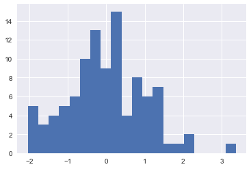

```python
# Se não quisermos ter que digitar randn toda vez podemos importar com um outro nome
from numpy.random import randn as rnd

print(rnd(10))

# outro exemplo
from matplotlib.pyplot import hist, show

# podemos plotar um histograma com os valores aleatórios gerados
hist(rnd(100), bins=20)
show()
```

```python
# Digamos que existem 2 funções no módulo numpy que iremos usar
# podemos importar as duas simultaneamente da seguinte maneira
from numpy import ones, zeros

print(ones((3,4)))
print(zeros((2,5)))
```

```
[[ 1.  1.  1.  1.]
 [ 1.  1.  1.  1.]
 [ 1.  1.  1.  1.]]
[[ 0.  0.  0.  0.  0.]
 [ 0.  0.  0.  0.  0.]]
```

```python
# Se quisermos importar todas as funções de um determinado módulo
# podemos fazer isso usando o caractere especial '*'
from numpy import *

# deste modo todas as classes e sub-modulos contidos em numpy foram importados e para
# usa-los não é necessário digitar numpy.nome_da_função toda vez

print(random.randn(10))
print(ones((2,5)))
print(mean(rnd_normal))
```

```
[-0.63031801 -0.38207512  0.2640805   1.9703187  -0.23245257  1.67891109
  0.38425385 -2.35078441  0.24589248  1.09723994]
[[ 1.  1.  1.  1.  1.]
 [ 1.  1.  1.  1.  1.]]
27.585670821
```

```python
# lembrando que para listar todos as funções/classes/métodos em um módulo basta usar
# a função dir() e para obter informações sobre uma função específica podemos usar a função help
# note que é necessário importar o módulo para usar dir, mas podemos usar a função help e ler
# a documentação do módulo, passando como argumento uma string com o nome do módulo
```

### Lista de Módulos Importantes

A seguir é dada uma lista de módulos importantes para a realização de diversas funcionalidades. Note que nem todos os módulos estão disponíveis na instalação padrão da distribuição Anaconda. Também é importante notar que o nome para importação do módulo em um programa pode ser diferente. Pesquise por tutoriais e verifique a documentação do módulo antes de usá-lo.

#### Numpy:

Numpy é o principal módulo para computação numérica em Python, contendo um tipo de objeto vetorial que permite a criação e manipulação de vetores e matrizes N-dimensionais de maneira extremamente rápida e eficiente. Contém praticamente todas as funções matemáticas básicas, incluindo funções trigonométricas, métodos para álgebra linear, transformada de Fourier e geração de números aleatórios. Numpy é possivelmente o módulo externo mais importante para análise, manipulação de dados e matemática computacional.

#### Matplotlib, Seaborn, Bokeh e Plotly:

Módulos para visualização de gráficos. Matplotlib é o pacote padrão para lidar com gráficos 2D e realiza, basicamente, as mesmas funcionalidades gráficas do software MATLAB. Seaborn é escrito a partir de matplotlib e expande suas funcionalidades permitindo a criação de gráficos complexos e atrativos em poucas linhas de código. Bokeh e Plotly geram gráficos iterativos em formato HTML, rodando em um web browser.

#### Pandas:

Pandas é um módulo que facilita enormemente a manipulação de dados estruturados, tendo um objeto tipo dataframe que funciona como uma tabela. Existem uma série de funções e métodos que permitem a importação e a exportação de dados em uma variedade de formatos (CSV, Excel, JSON, Texto, etc). O pacote também conta com funções estatísticas básicas que podem ser implementadas diretamente nos objetos de dados, facilitando a realização de análises exploratórias rápidas.

#### SciPy:

Conta com sub-módulos para análise estatística, implementação de métodos para manipulação de sinais, análise de sistemas dinâmicos lineares, métodos para realização de convolução, correlação, transformada de Fourier, entre diversas outras funções. Também possui um sub-módulo para leitura e gravação de áudio.

#### Statsmodels:

Biblioteca especializada em métodos e modelos estatísticos. É mais completa que o sub-módulo 'stats' da biblioteca SciPy.

#### SymPy:

Módulo para realização de matemática simbólica, permitindo a solução de sistemas lineares, solução de equações diferenciais, cálculo de limites, derivada, integral, etc.

#### SciKit-learn, TensorFlow e Keras:

Módulos especializados na implementação de algorítimos para machine-learning e inteligência artificial. Scikit-learn contém os métodos mais utilizados. TensorFlow e Keras são especializados em redes neurais e deep-learning.

#### SQLite3, PyMsSQL, SQLAlchemy e Peewee:

Módulos para a criação e manipulação de databases em SQL (Structured Querry Language). Permite a conexão com databases existentes, iteração com softwares especializados e realização de queries em linguagem SQL.

#### Datetime e Arrow:

Datetime é a biblioteca padrão em Python para lidar com datas e horário e Arrow é um novo módulo que simplifica estas operações.

#### Os e Shutil:

Os permite lidar com dependências funcionais do sistema operacionais, incluindo a manipulação de diretórios, leitura de nomes de arquivos e pastas. Útil para obter os nomes dos arquivos em uma pasta, buscar por arquivos com uma extensão específica ou renomear arquivos. Com o módulo shutil é possível copiar e deletar arquivos.

#### Sh:

Permite a chamada e a execução de comandos de qualquer programa externo, retornando os resultados para um programa em python.

#### Cython:

Aumenta a performance (velocidade de execução) do código Python compilando ele em linguagem C.

#### Python-docx e xlsxWriter:

Módulos para criação e manipulação de arquivos .docx e .xlsx, do Microsoft Word e Excel respectivamente.

#### Pillow e PIL:

Módulos para manipulação e processamento de imagens. PIL é a biblioteca padrão e Pillow uma atualização que permite a execução das mesmas funcionalidades (e outras mais) de maneira simplificada.

#### OpenCV:

Biblioteca escrita em C++ com inúmeras funções, métodos e modelos para manipulação, processamento de imagens e implementação de algoritmos de detecção de padrões e visão computacional. Módulo extremamente poderoso e completo, porém, de uso complexo.

#### Tkinter, PyQt, WxPython e Gooey:

Bibliotecas para a criação de programas com interface fráfica (GUI - Graphical User Interface). Tkinter, PyQt e WxPython são concorrentes, tendo basicamente as mesmas funcionalidades, e Gooey é especialmente recomendado para a conversão de programas baseados em terminal de comando para GUIs equivalentes.

#### Py2exe, CxFreeze e PyInstaller:

Utilizadas para a criação de aplicações stand-alone, para que o programa desenvolvido rode em qualquer computador sem a necessidade de ter o Python instalado.

#### Nose e PyTest:

Utilizadas para teste de programas.

#### Requests, Beautiful Soup, Selenium e Scrapy:

Requests é o módulo padrão para abrir páginas da web. Beautifoul Soup permite a aquisição do código HTML de uma página de maneira organizada e a busca e extração de dados relativos as tags contidas no código HTML. Selenium permite a iteração com sites (web driver) e Scrapy facilita a aquisição de dados em formatos e estruturas específicas (buscar e copiar todas os arquivos com um determinado formato em um site). Estas ferramentas podem ser utilizadas em conjunto para realizar tarefas de web-scrapping complexas.

#### Flask e Django:

Frameworks para o desenvolvimento de sites e aplicações na web. Django é recomendável para projetos maiores e Flask é utilizado para desenvolver pequenos projetos rapidamente.

#### PyGame, Pyglet e Panda3D:

Pacotes para criação de jogos e interface multimídia com áudio e vídeo. Panda3D é o módulo mais complexo, possibilitando a criação de jogos 3D.

Para maiores detalhes pesquisar pela documentação específica do módulo. Em geral, todos os módulos apresentados possuem diversos tutoriais e uma ampla comunidade de usuários dispostos a ajudar e responder perguntas. O melhor site para sanar dúvidas de programação é o StackOverflow.

### Exercícios:

É importante praticar os conceitos aprendidos, por isso foram desenvolvidos exercícios que requerem a aplicação de boa parte das funcionalidades vistas ao longo do curso. Os problemas aqui propostos são relativamente simples e podem ser resolvidos com poucas linhas de código.

1. Foi gerado um arquivo 'measurements.csv' com resultados de medidas de um determinado processo de fabricação. A medição realizada diz respeito a tensão de threshold de transistores do tipo n-MOSFET, que deve estar entre 0.65V e 0.75V. Crie um programa que conta o número de medidas fora do intervalo especificado e imprime a porcentagem de medidas acima do limite superior (0.75) e abaixo do limite inferior (0.65). Dica: você pode usar o método split para converter uma string em lista, lembrando que o caractere que separa linhas é o "\n". Desafio, tente resolver em 8 linhas ou menos.
2. Baseados nos dados da questão anterior, crie um programa que gera um arquivo .csv com duas colunas, uma correspondente aos valores medidos, e outra contendo dois valores possíveis de string: 'PASS', caso os valores das medidas estejam dentro do intervalo aceitável (0.65 a 0.75) e 'FAIL', caso não estejam. Desafio, tente resolver em 7 linhas ou menos.
3. Modifique o programa da questão 1 para ser uma função que recebe como entrada o nome do arquivo contendo as medidas e retorna um tuple com a porcentagem (em float) de valores abaixo do limite inferior e acima do limite superior.